# Pertemuan 2_Regresi_Data Repsol

Syifa Khairunnisa

2023-09-09

```r
library(dplyr)
library(TTR)
library(forecast)
library(lmtest) #digunakan untuk uji formal pendeteksian autokorelasi
library(orcutt) #untuk membuat model regresi Cochrane-Orcutt
library(HoRM) #untuk membuat model regresi Hildreth-Lu
```

## Input Data

Data asli yang digunakan berasal dari tautan berikut. https://www.kaggle.com/datasets/lucastrenzado/repsol-stock-data-20-years Namun, kali ini hanya digunakan beberapa peubah yaitu, harga tertinggi (high) sebagai peubah respon, dan harga pembukaan (open) serta harga terendah (low) sebagai peubah penjelas. Data tersebut juga akan dipangkas, sehingga periode yang digunakan adalah dari Desember 2021-September 2022, dengan jumlah amatan sebanyak 210.

```r
library(rio)
data <- import("https://raw.githubusercontent.com/syifaskn/MPDWPraktikum/main/Pertemuan%202/RepsolDes21Sep22.csv")
data
```

```
##           date   open   high    low  close   volume
## 1   2021-12-07 10.380 10.540 10.320 10.396  6465853
## 2   2021-12-08 10.352 10.430 10.198 10.310  4025443
## 3   2021-12-09 10.324 10.354 10.100 10.136  3426217
## 4   2021-12-10 10.114 10.212 10.060 10.100  5451872
## 5   2021-12-13 10.144 10.274  9.885  9.885  4392608
## 6   2021-12-14  9.930 10.074  9.896  9.994  4966050
## 7   2021-12-15  9.985 10.000  9.793  9.820  8535522
## 8   2021-12-16  9.930 10.078  9.903  9.998  7711773
## 9   2021-12-17  9.917  9.989  9.832  9.943 30050546
## 10  2021-12-20  9.690  9.876  9.630  9.842 18273226
## 11  2021-12-21  9.980 10.112  9.862 10.080  7629950
## 12  2021-12-22 10.088 10.172 10.020 10.152  3343479
## 13  2021-12-23 10.178 10.442 10.152 10.374  7561362
## 14  2021-12-27 10.296 10.576 10.274 10.504  4732857
```

[output cut: 196 more lines]

```r
View(data)
```

Sebelum melakukan regresi, akan diperlihatkan *plot time-series* dari harga tertinggi yang ditawarkan pada stock repsol perhari pada periode Desember 2021-September 2022.

```r
#Membentuk objek time series
data.ts<-ts(data$high)
data.ts
```

```
## Time Series:
## Start = 1
## End = 210
## Frequency = 1
##   [1] 10.540 10.430 10.354 10.212 10.274 10.074 10.000 10.078  9.989  9.876
##  [11] 10.112 10.172 10.442 10.576 10.666 10.624 10.510 10.696 10.976 11.190
##  [21] 11.246 10.968 10.912 10.902 11.178 11.200 11.266 11.276 11.290 11.410
##  [31] 11.084 10.754 10.736 10.734 11.134 11.374 11.350 11.294 11.426 11.432
##  [41] 11.426 11.586 11.594 11.814 11.644 11.816 11.882 11.986 11.750 11.976
##  [51] 12.000 12.036 11.818 11.770 11.632 11.398 11.736 11.746 11.992 12.366
##  [61] 12.676 11.980 12.096 12.372 12.468 11.988 11.980 11.664 11.468 11.642
##  [71] 11.548 11.600 11.650 11.832 12.144 12.204 12.194 12.306 12.170 12.046
##  [81] 12.062 12.005 12.065 12.200 12.420 12.380 12.830 12.930 13.275 13.580
##  [91] 13.815 14.075 13.810 13.790 13.535 13.090 12.960 12.985 13.650 14.330
## [101] 14.240 14.230 14.545 14.640 14.940 14.795 13.715 14.255 14.285 14.330
## [111] 14.250 14.795 14.875 14.865 14.750 14.840 14.795 15.150 15.105 15.030
## [121] 15.065 15.310 15.190 15.055 15.160 15.450 16.045 16.120 16.230 15.895
## [131] 15.380 15.585 15.370 15.070 14.435 14.090 14.330 13.965 13.940 13.830
## [141] 14.000 14.320 14.410 14.235 14.080 13.950 13.565 12.970 13.180 13.365
## [151] 13.015 12.990 12.290 12.210 12.030 12.285 12.120 12.265 12.140 12.070
## [161] 12.240 12.530 12.620 12.600 12.235 12.200 12.000 12.150 12.135 11.895
## [171] 12.115 12.480 12.480 12.585 12.900 12.735 12.780 12.680 13.040 13.180
## [181] 13.285 13.730 13.690 13.610 13.545 13.650 13.815 13.220 13.005 13.440
## [191] 13.765 13.840 13.665 13.115 13.170 13.445 13.250 13.035 12.930 12.385
## [201] 12.155 12.195 12.370 12.155 11.920 11.470 11.705 11.905 11.865 11.995
```

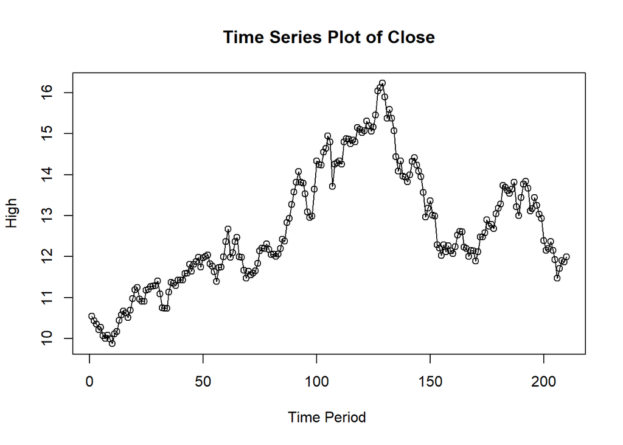

```r
#Membuat plot time series
ts.plot(data.ts, xlab="Time Period ", ylab="High", main= "Time Series Plot of Close")
points(data.ts)
```

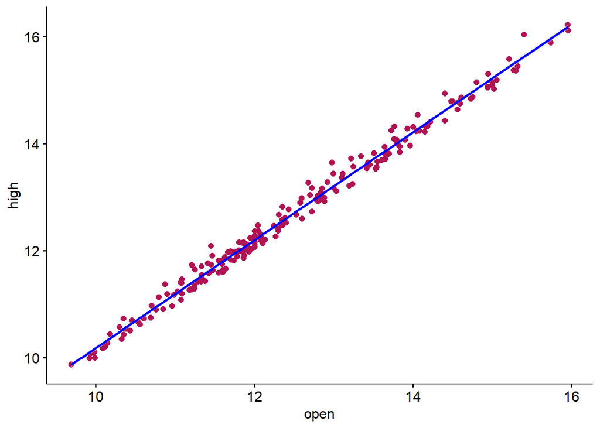

```r
#Eksplorasi Data
library(ggpubr)
ggscatter(data,x = "open",y="high",color="#b01453",
 add = "reg.line" , # Add regression line
 conf.int = TRUE, # Add confidence interval
 add.params = list(color = "blue",
 fill = "lightgray"))
```

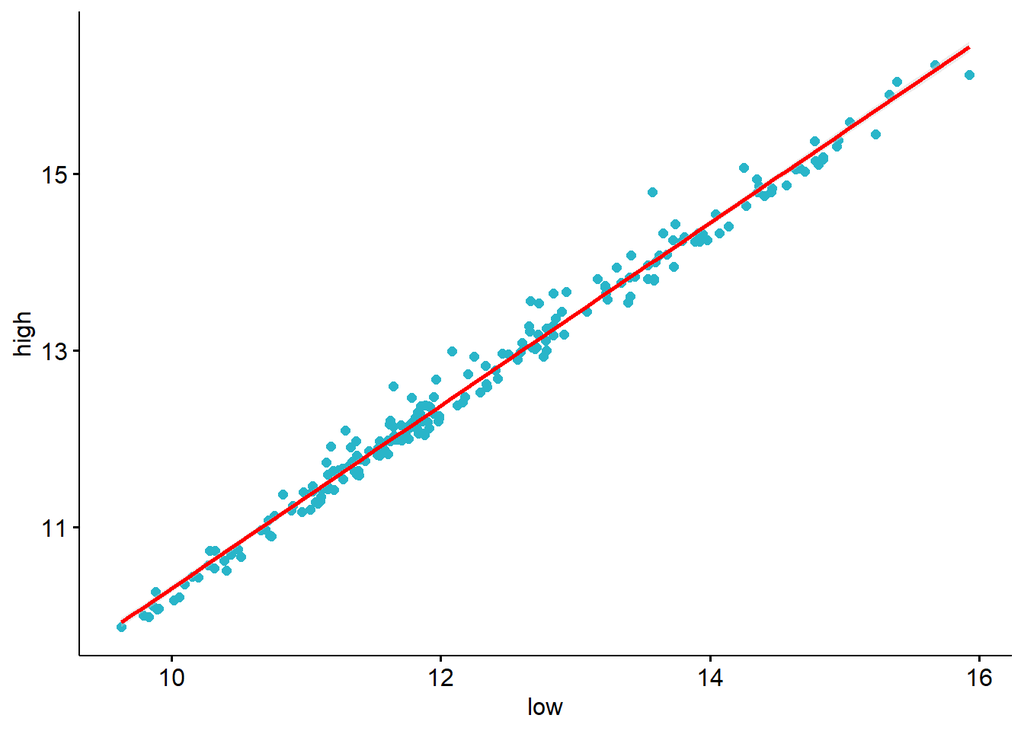

```r
ggscatter(data,x = "low",y="high",color="#29b5c9",
 add = "reg.line" , # Add regression line
 conf.int = TRUE, # Add confidence interval
 add.params = list(color = "red",
 fill = "lightgray"))
```